# Get Started: Optimize!

In this tutorial, we want to use `Manopt.jl` solve the optimization problem

$$\operatorname*{argmin}_{p ∈ \mathcal M} f(p)$$

where $\mathcal M$ is a [Riemannian manifold](https://juliamanifolds.github.io/Manifolds.jl/stable/interface.html#ManifoldsBase.Manifold) and $f:\mathcal M → ℝ$ is the cost function.

We will take a loot at how to define the optimisation problem, that is the manifold, the cost functin and (in our example) a gradient to call one specific solver.

After that we will dive into general keyword arguments that are available for all solvers as well as specific keywords that are available for the solver we consider here.

We will finally consider a nonsmooth example with a second, a little bit more complicated solver.

This tutorial is a [Pluto 🎈 notebook](https://github.com/fonsp/Pluto.jl), so if you are reading the `Manopt.jl` documentation you can also [download](https://github.com/JuliaManifolds/Manopt.jl/raw/master/tutorials/Optimize!.jl) the notebook and run it yourself within Pluto.

## Setup

If you open this notebook in Pluto locally it switches between two modes. If the tutorial is within the `Manopt.jl` repository, this notebook tries to use the local package in development mode. Otherwise, the file uses the Pluto pacakge management version. In this case, the includsion of images might be broken. unless you create a subfolder `optimize` and activate `asy`-rendering.

Since the loading is a little complicated, we show, which versions of packages were installed in the following.

```julia
with_terminal() do
    Pkg.status()
end
```

```
�[32m�[1mStatus�[22m�[39m `/private/var/folders/_v/wg192lpd3mb1lp55zz7drpcw0000gn/T/jl_xk2QoW/Project.toml`
 �[90m [5ae59095] �[39mColors v0.12.10
 �[90m [1cead3c2] �[39mManifolds v0.8.42
 �[90m [0fc0a36d] �[39mManopt v0.4.0 `~/Repositories/Julia/Manopt.jl`
 �[90m [7f904dfe] �[39mPlutoUI v0.7.49
 �[90m [44cfe95a] �[39mPkg v1.8.0
 �[90m [9a3f8284] �[39mRandom
```

# Example

To get started with our example we first have to load the necessary packages.

Let's load a few colors from [Paul Tol](https://personal.sron.nl/~pault/).

```julia
begin
    black = RGBA{Float64}(colorant"#000000")
    TolVibrantOrange = RGBA{Float64}(colorant"#EE7733")
    TolVibrantBlue = RGBA{Float64}(colorant"#0077BB")
    TolVibrantTeal = RGBA{Float64}(colorant"#009988")
    TolVibrantMagenta = RGBA{Float64}(colorant"#EE3377")
end;
```

# The data set

We take a look at a srandom set of points.

```julia
begin
    n = 100
    σ = π / 8
    M = Sphere(2)
    x = 1 / sqrt(2) * [1.0, 0.0, 1.0]
    Random.seed!(42)
    data = [exp(M, x,  σ * rand(M; vector_at=x)) for i in 1:n]
end
```

```
100-element Vector{Vector{Float64}}:
 [0.9013817292525768, -0.3266930346539438, 0.2842228690275139]
 [0.5413128376734956, -0.27073756886516653, 0.7960411927625647]
 [0.1164070355067573, 0.22835279004025902, 0.9665942299462364]
 [0.8120710958917794, 0.3048940575972932, 0.4975742646670772]
 [0.34037597269891057, 0.16278898828946248, 0.9260906772562628]
 [0.7937947657628919, -0.11512297480761367, 0.5971905646599591]
 [0.8657115032997768, 0.0994828021701859, 0.49055760632856193]
 ⋮
 [-0.2454023055635139, 0.6192543288278474, 0.7458564102104936]
 [0.7206649443671708, 0.026606223795364103, 0.6927727959552205]
 [-0.1556170638176625, 0.4709844443817593, 0.8683069633483166]
 [0.864645918606244, 0.15287339377544437, 0.47855737473488213]
 [0.8283553683993905, 0.539804408097735, 0.14979514225155605]
 [0.7766227187182986, -0.11478608022900104, 0.6194201389656778]
```

```julia
asymptote_export_S2_signals(
    image_prefix * "/startDataAndCenter.asy";
    points=[[x], data],
    colors=Dict(:points => [TolVibrantBlue, TolVibrantTeal]),
    dot_size=3.5,
    camera_position=(1.0, 0.5, 0.5),
)
```

```julia
render_asy && render_asymptote(image_prefix * "/startDataAndCenter.asy"; render=2)
```

```
false
```

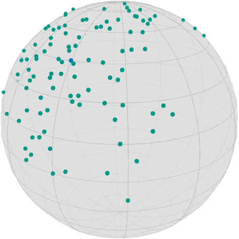

## Computing the Mean

To compute the mean on the manifold we use the characterization that the Euclidean mean minimizes the sum of squared distances, and end up with the following cost function. Its minimizer is called [Riemannian Center of Mass](https://arxiv.org/abs/1407.2087).

> **Note.** There are more sophisticated methods tailored for the specific manifolds available in [Manifolds.jl](https://juliamanifolds.github.io/Manifolds.jl/) see [mean](https://juliamanifolds.github.io/Manifolds.jl/stable/features/statistics.html#Statistics.mean-Tuple{Manifold,AbstractArray{T,1}%20where%20T,AbstractArray{T,1}%20where%20T,ExtrinsicEstimation}).

```julia
F(M, y) = sum(1 / (2 * n) * distance.(Ref(M), Ref(y), data) .^ 2)
```

```
F (generic function with 1 method)
```

```julia
gradF(M, y) = sum(1 / n * grad_distance.(Ref(M), data, Ref(y)))
```

```
gradF (generic function with 1 method)
```

Note that the grad_distance defaults to the case `p=2`, i.e. the gradient of the squared distance. For details on convergence of the gradient descent for this problem, see [AfsariTronVidal2013].

The easiest way to call the gradient descent is now to call gradient_descent.

```julia
gradient_descent(M, F, gradF, data[1])
```

```
3-element Vector{Float64}:
 0.6868392795563908
 0.006531600623587405
 0.7267799820108911
```

In order to get more details, we further add the `debug=` keyword argument, which act as a [decorator pattern](https://en.wikipedia.org/wiki/Decorator_pattern).

The following debug prints

```markdown
# i | Last Change: | F(x): | x:
```

as well as the reason why the algorithm stopped at the end.

The elements passed to `debug=` are postprocessed, there are specifiic symbols and formats we can use. For example `:Iteration` to plot the iteratin, but we can also add a format for the print using `(:Change, "| Last change: %e3.8")`, i.e. the second string is a format for printf.

Note that here we use `PlutoUI` to see the output also here in the notebook

```julia
with_terminal() do
    global xMean = gradient_descent(
        M,
        F,
        gradF,
        data[1];
        debug=[
            :Iteration,
            (:Change, "change: %1.9f | "),
            (:Cost, " F(x): %1.11f | "),
            "\n",
            :Stop,
        ],
    )
end
```

```
Initial  F(x): 0.32487988924 |
# 1     change: 1.063609017 |  F(x): 0.25232524046 |
# 2     change: 0.809858671 |  F(x): 0.20966960102 |
# 3     change: 0.616665145 |  F(x): 0.18546505598 |
# 4     change: 0.470841764 |  F(x): 0.17121604104 |
# 5     change: 0.359345690 |  F(x): 0.16300825911 |
# 6     change: 0.274597420 |  F(x): 0.15818548927 |
# 7     change: 0.209754141 |  F(x): 0.15538859091 |
# 8     change: 0.160325726 |  F(x): 0.15374833028 |
# 9     change: 0.122511985 |  F(x): 0.15279385440 |
# 10    change: 0.093649597 |  F(x): 0.15223486707 |
# 11    change: 0.071574879 |  F(x): 0.15190899622 |
# 12    change: 0.054714511 |  F(x): 0.15171831716 |
# 13    change: 0.041821775 |  F(x): 0.15160704289 |
# 14    change: 0.031970876 |  F(x): 0.15154196576 |
# 15    change: 0.024439028 |  F(x): 0.15150396567 |
# 16    change: 0.018682961 |  F(x): 0.15148174825 |
# 17    change: 0.014282240 |  F(x): 0.15146877013 |
# 18    change: 0.010918624 |  F(x): 0.15146118336 |
# 19    change: 0.008347087 |  F(x): 0.15145675056 |
# 20    change: 0.006381403 |  F(x): 0.15145415941 |
# 21    change: 0.004878615 |  F(x): 0.15145264521 |
# 22    change: 0.003729811 |  F(x): 0.15145176011 |
# 23    change: 0.002851533 |  F(x): 0.15145124284 |
# 24    change: 0.002180104 |  F(x): 0.15145094047 |
# 25    change: 0.001666780 |  F(x): 0.15145076374 |
# 26    change: 0.001274339 |  F(x): 0.15145066044 |
# 27    change: 0.000974303 |  F(x): 0.15145060005 |
# 28    change: 0.000744917 |  F(x): 0.15145056476 |
# 29    change: 0.000569540 |  F(x): 0.15145054412 |
# 30    change: 0.000435456 |  F(x): 0.15145053206 |
# 31    change: 0.000332941 |  F(x): 0.15145052501 |
# 32    change: 0.000254561 |  F(x): 0.15145052089 |
# 33    change: 0.000194635 |  F(x): 0.15145051848 |
# 34    change: 0.000148817 |  F(x): 0.15145051707 |
# 35    change: 0.000113785 |  F(x): 0.15145051625 |
# 36    change: 0.000087000 |  F(x): 0.15145051577 |
# 37    change: 0.000066521 |  F(x): 0.15145051549 |
# 38    change: 0.000050862 |  F(x): 0.15145051532 |
# 39    change: 0.000038890 |  F(x): 0.15145051523 |
# 40    change: 0.000029736 |  F(x): 0.15145051517 |
# 41    change: 0.000022737 |  F(x): 0.15145051514 |
# 42    change: 0.000017385 |  F(x): 0.15145051512 |
# 43    change: 0.000013293 |  F(x): 0.15145051511 |
# 44    change: 0.000010164 |  F(x): 0.15145051510 |
# 45    change: 0.000007772 |  F(x): 0.15145051510 |
# 46    change: 0.000005942 |  F(x): 0.15145051509 |
# 47    change: 0.000004544 |  F(x): 0.15145051509 |
# 48    change: 0.000003474 |  F(x): 0.15145051509 |
# 49    change: 0.000002657 |  F(x): 0.15145051509 |
# 50    change: 0.000002031 |  F(x): 0.15145051509 |
# 51    change: 0.000001554 |  F(x): 0.15145051509 |
# 52    change: 0.000001188 |  F(x): 0.15145051509 |
# 53    change: 0.000000909 |  F(x): 0.15145051509 |
# 54    change: 0.000000695 |  F(x): 0.15145051509 |
# 55    change: 0.000000532 |  F(x): 0.15145051509 |
# 56    change: 0.000000408 |  F(x): 0.15145051509 |
# 57    change: 0.000000313 |  F(x): 0.15145051509 |
# 58    change: 0.000000240 |  F(x): 0.15145051509 |
# 59    change: 0.000000185 |  F(x): 0.15145051509 |
# 60    change: 0.000000143 |  F(x): 0.15145051509 |
# 61    change: 0.000000112 |  F(x): 0.15145051509 |
# 62    change: 0.000000084 |  F(x): 0.15145051509 |
# 63    change: 0.000000063 |  F(x): 0.15145051509 |
# 64    change: 0.000000052 |  F(x): 0.15145051509 |
# 65    change: 0.000000047 |  F(x): 0.15145051509 |
# 66    change: 0.000000042 |  F(x): 0.15145051509 |
# 67    change: 0.000000042 |  F(x): 0.15145051509 |
# 68    change: 0.000000039 |  F(x): 0.15145051509 |
The algorithm reached approximately critical point after 68 iterations; the gradient norm (4.954832225480352e-10) is less than 1.0e-9.
```

While this works fine and finds a point with a very small gradient norm, the default way to determine the stepsize (though using [`ArmijoLinesearch`](https://manoptjl.org/stable/plans/index.html#Manopt.ArmijoLinesearch)) might be a little bit conservative, since for a start we aim for robust defaults.

We can tweak the default values for the `contraction_factor` and the `sufficient_decrease` of the Armijo linesearch to improve there. We can further use the `:Stepsize` symbol in the `debug=` specification to also print the obtained step size by Armijo. We get

```julia
with_terminal() do
    global xMean2 = gradient_descent(
        M,
        F,
        gradF,
        data[1];
        stepsize=ArmijoLinesearch(M; contraction_factor=0.999, sufficient_decrease=0.5),
        debug=[
            :Iteration,
            (:Change, "change: %1.9f | "),
            (:Cost, " F(x): %1.11f | "),
            (:Stepsize, " | s: %1.3f"),
            "\n",
            :Stop,
        ],
    )
end
```

```
Initial  F(x): 0.32487988924 |
# 1     change: 0.603006286 |  F(x): 0.15145133383 |  | s: 1.049
# 2     change: 0.001318138 |  F(x): 0.15145051509 |  | s: 1.062
# 3     change: 0.000001034 |  F(x): 0.15145051509 |  | s: 1.061
# 4     change: 0.000000021 |  F(x): 0.15145051509 |  | s: 1.060
# 5     change: 0.000000021 |  F(x): 0.15145051509 |  | s: 1.060
The algorithm reached approximately critical point after 5 iterations; the gradient norm (3.506968695957415e-11) is less than 1.0e-9.
```

which finishes in 5 steaps, with (numerically) the same cost.

```julia
F(M, xMean) - F(M, xMean2)
```

```
2.7755575615628914e-16
```

Note that other optimization tasks may have other speedup opportunities.

For even more precision, we can further require a smaller gradient norm. This is done by changing the `StoppingCriterion` used, where several criteria can be combined using `&` and/or `|`. For example in the following case, we want to stop if either the gradient norm is *very* small (`1e-15`) or if we reach 200 iterations, which can be seen as a fallback.

```julia
with_terminal() do
    global xMean3 = gradient_descent(
        M,
        F,
        gradF,
        data[1];
        stepsize=ArmijoLinesearch(M; contraction_factor=0.999, sufficient_decrease=0.5),
        debug=[
            :Iteration,
            (:Change, "change: %1.9f | "),
            (:Cost, " F(x): %1.11f | "),
            (:Stepsize, " | s: %1.3f"),
            "\n",
            :Stop,
        ],
        stopping_criterion=StopWhenGradientNormLess(1e-15) | StopAfterIteration(200),
    )
end
```

```
Initial  F(x): 0.32487988924 |
# 1     change: 0.603006286 |  F(x): 0.15145133383 |  | s: 1.049
# 2     change: 0.001318138 |  F(x): 0.15145051509 |  | s: 1.062
# 3     change: 0.000001034 |  F(x): 0.15145051509 |  | s: 1.061
# 4     change: 0.000000021 |  F(x): 0.15145051509 |  | s: 1.060
# 5     change: 0.000000021 |  F(x): 0.15145051509 |  | s: 1.060
# 6     change: 0.000000021 |  F(x): 0.15145051509 |  | s: 1.054
# 7     change: 0.000000015 |  F(x): 0.15145051509 |  | s: 1.054
# 8     change: 0.000000021 |  F(x): 0.15145051509 |  | s: 1.054
The algorithm reached approximately critical point after 8 iterations; the gradient norm (2.350494298836896e-17) is less than 1.0e-15.
```

Let's add this point to our data image

```julia
asymptote_export_S2_signals(
    image_prefix * "/startDataCenterMean.asy";
    points=[[x], data, [xMean3]],
    colors=Dict(:points => [TolVibrantBlue, TolVibrantTeal, TolVibrantOrange]),
    dot_size=3.5,
    camera_position=(1.0, 0.5, 0.5),
)
```

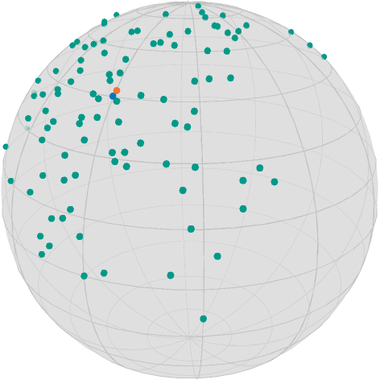

```julia
render_asy && render_asymptote(image_prefix * "/startDataCenterMean.asy"; render=2);
```

## Computing the Median

> **Note.** There are more sophisticated methods tailored for the specific manifolds available in [Manifolds.jl](https://juliamanifolds.github.io/Manifolds.jl/) see [`median`](https://juliamanifolds.github.io/Manifolds.jl/stable/features/statistics.html#Statistics.median-Tuple{Manifold,AbstractArray{T,1}%20where%20T,AbstractArray{T,1}%20where%20T,CyclicProximalPointEstimation}).

Similarly to the mean, you can also define the median as the minimizer of the distances, see for example [Bačák2014], but since this problem is not differentiable, we employ the Cyclic Proximal Point (CPP) algorithm, described in the same reference. We define

```julia
F2(M, y) = sum(1 / (2 * n) * distance.(Ref(M), Ref(y), data))
```

```
F2 (generic function with 1 method)
```

```julia
proxes = Function[(M, λ, y) -> prox_distance(M, λ / n, di, y, 1) for di in data]
```

```
100-element Vector{Function}:
 #5 (generic function with 1 method)
 #5 (generic function with 1 method)
 #5 (generic function with 1 method)
 #5 (generic function with 1 method)
 #5 (generic function with 1 method)
 #5 (generic function with 1 method)
 #5 (generic function with 1 method)
 ⋮
 #5 (generic function with 1 method)
 #5 (generic function with 1 method)
 #5 (generic function with 1 method)
 #5 (generic function with 1 method)
 #5 (generic function with 1 method)
 #5 (generic function with 1 method)
```

So we call the cyclic proximal point algorithm, this time with a recording, and activate the return of the complete options to access the recorded values. We further increase the display of the cost function to more digits.

```julia
with_terminal() do
    global o = cyclic_proximal_point(
        M,
        F2,
        proxes,
        data[1];
        debug=[
            :Iteration,
            " | ",
            :Change,
            " | ",
            (:Cost, "F(x): %1.12f"),
            " | ",
            :Iterate,
            "\n",
            50,
            :Stop,
        ],
        record=[:Iteration, :Change, :Cost, :Iterate],
        return_state=true,
    )
end
```

```
Initial  |  | F(x): 0.362208118208 |
# 50     | Last Change: 0.134517 | F(x): 0.244370141855 | p: [0.6899935005916554, -0.01896177317094576, 0.7235671498205909]
# 100    | Last Change: 0.000738 | F(x): 0.244369477428 | p: [0.6896989553827805, -0.019620062719681402, 0.7238303696880809]
# 150    | Last Change: 0.000249 | F(x): 0.244369347858 | p: [0.6896277093923412, -0.019858554704607363, 0.7238917462185613]
# 200    | Last Change: 0.000125 | F(x): 0.244369301328 | p: [0.6895992327648923, -0.01998169958313013, 0.7239154852963934]
# 250    | Last Change: 0.000075 | F(x): 0.244369279442 | p: [0.6895849904297641, -0.020056887244235364, 0.7239269730077793]
# 300    | Last Change: 0.000050 | F(x): 0.244369267418 | p: [0.6895768884180586, -0.020107567336531056, 0.7239332846993344]
# 350    | Last Change: 0.000036 | F(x): 0.244369260105 | p: [0.6895718777269854, -0.02014404303267818, 0.7239370435185869]
# 400    | Last Change: 0.000027 | F(x): 0.244369255326 | p: [0.6895685928055627, -0.020171551692442124, 0.7239394065241377]
# 450    | Last Change: 0.000021 | F(x): 0.244369252032 | p: [0.6895663455251911, -0.020193037616744812, 0.7239409481103398]
The algorithm performed a step with a change (0.0) less than 1.0000000000000002e-12.
```

```julia
xMedian = get_solver_result(o)
```

```
3-element Vector{Float64}:
  0.6895661616463946
 -0.02019493026914634
  0.7239410704634458
```

where the differences to `gradient_descent` are as follows

- the third parameter is now an Array of proximal maps
- debug is reduced to only every 50th iteration
- we further activated a `RecordAction` using the `record=` optional parameter. These work very similarly to those in debug, but they collect their data in an array. The high level interface then returns two variables; the `values` do contain an array of recorded datum per iteration. Here a tuple containing the iteration, last change and cost respectively; see [RedordOptions](https://manoptjl.org/stable/plans/index.html#RecordSolverState-1) for details.

We can access the recorded values using `get_record`, that consists of a tuple per iteration and contains the iteration number, the change and the cost.

```julia
values = get_record(o)
```

```
455-element Vector{Tuple{Int64, Float64, Float64, Vector{Float64}}}:
 (1, 0.0, 0.25122077492914474, [0.7725364607817968, -0.07080234064197363, 0.6310106538897341])
 (2, 0.07946683931821587, 0.24559809471687602, [0.7299963552108887, -0.02822518141887079, 0.6828679671156682])
 (3, 0.025458747868809976, 0.2447656389226173, [0.7136354125490966, -0.01937525066764777, 0.7002493110438962])
 (4, 0.011128576957066011, 0.24455205841482017, [0.7060405381827374, -0.016820341944346166, 0.7079716339935572])
 (5, 0.0060558247323271395, 0.2444726423122775, [0.7018014581124853, -0.01589109362362356, 0.7121953289194127])
 (6, 0.0037583754395985208, 0.2444355426751994, [0.6991317792895254, -0.015584930889514261, 0.7148229606809153])
 (7, 0.002537476812531073, 0.24441546613892304, [0.6973159854821999, -0.01555143996787514, 0.716595122161673])
 ⋮
 (450, 1.8005141576520485e-7, 0.24436925203177765, [0.6895663455251911, -0.020193037616744812, 0.7239409481103398])
 (451, 1.7249341164216756e-7, 0.2443692519766888, [0.6895663082401094, -0.020193419455300652, 0.723940972974227])
 (452, 1.541388099311085e-7, 0.24436925192196485, [0.6895662712118455, -0.02019379962900415, 0.7239409976397221])
 (453, 1.1733186057227575e-7, 0.24436925186759026, [0.6895662344382356, -0.020194178148717032, 0.7239410221085973])
 (454, 4.2146848510894035e-8, 0.24436925181357574, [0.6895661979171257, -0.020194555025206402, 0.7239410463825939])
 (455, 0.0, 0.244369251759909, [0.6895661616463946, -0.02019493026914634, 0.7239410704634458])
```

```julia
asymptote_export_S2_signals(
    image_prefix * "/startDataCenterMedianAndMean.asy";
    points=[[x], data, [xMean], [xMedian]],
    colors=Dict(
        :points => [TolVibrantBlue, TolVibrantTeal, TolVibrantOrange, TolVibrantMagenta]
    ),
    dot_size=3.5,
    camera_position=(1.0, 0.5, 0.5),
)
```

```julia
render_asy && render_asymptote(image_prefix * "/startDataCenterMedianAndMean.asy"; render=2)
```

```
false
```

In the following image the mean (orange), median (magenta) are shown.

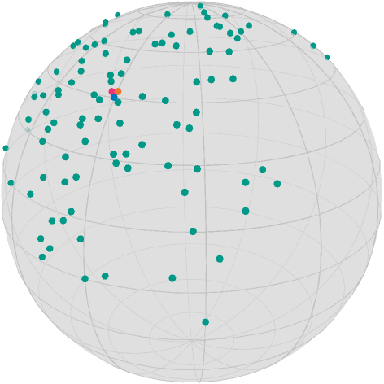

## Literature

Bačák2014

> Bačák, M: **Computing Medians and Means in Hadamard Spaces.** SIAM Journal on Optimization, Volume 24, Number 3, pp. 1542–1566, doi: 10.1137/140953393, arxiv: 1210.2145

AfsariTronVidal2013

> Afsari, B; Tron, R.; Vidal, R.: **On the Convergence of Gradient Descent for Finding the Riemannian Center of Mass**, SIAM Journal on Control and Optimization, Volume 51, Issue 3, pp. 2230–2260. doi: 10.1137/12086282X, arxiv: 1201.0925.